# Targeted Hormone-Gene Analysis: Published Gene Lists

Sneha M. Chaturvedi

Last updated 2026-09-04

| **Inputs** | Limma result CSVs from hormone–gene scripts, gene lists in `doc/gene_lists/` |
| --- | --- |
| **Outputs** | Overlap tables and figures in `results/gene-hormone/targeted_gene_list/` |
| **Upstream** | `testosterone_gene_limma.qmd`, `estradiol_progesterone_gene_limma.qmd` |
| **Downstream** | `gene_list_scatter.R` |

## Goals

Re-run limma-voom hormone-gene association models restricted to genes from published androgen-, estradiol-, and progesterone-response gene lists. FDR is recomputed within each gene-list-restricted set (targeted hypothesis testing). Models and thresholds are identical to the primary analysis.

**Gene lists:**

- **Testosterone:** Kelava et al. 2021 (*Nature*), Matassa et al. 2025, Li et al. 2024 (*Nature*, brain only), Bramble et al. 2016 (*Sci Rep*, XX + XY merged)
- **Estradiol:** Matassa et al. 2025
- **Progesterone:** Piechota et al. 2017 (*Sci Rep*, FDR < 20% astrocyte threshold per authors)

**Files required in `../../doc/gene_lists/`:**

- `kelava_2021_supp_table3.csv`
- `matassa_2025_gene_lists.csv`
- `li_2024_sex_diff_degs.xlsx`
- `bramble_2016_XX_TP.xls` (MOESM2)
- `bramble_2016_XY_TP.xls` (MOESM3)
- `Piechota_et_al_2017.xls`

## Set Up

```r
knitr::opts_chunk$set(echo = TRUE)

Packages <- c(
  "tidyverse", "Seurat", "Signac", "glue", "readxl", "cowplot",
  "edgeR", "limma", "patchwork", "svglite", "Matrix", "ggpubr",
  "biomaRt", "AnnotationDbi"
)
lapply(Packages, library, character.only = TRUE)
```

[output not shown]

[output not shown]

[output cut: 92 more lines]

```r
source("pseudobulk_functions.R")
root <- find_project_root()
set.seed(123)

gene_list_dir <- file.path(root, "doc/gene_lists")
out_dir_base  <- file.path(root, "results/gene-hormone/targeted_gene_list")
dir.create(out_dir_base, showWarnings = FALSE, recursive = TRUE)
```

```r
SSD_data <- readRDS(file.path(root, "data/cache/SSD_meta_umap.rds"))
pb_base  <- readRDS(file.path(root, "data/cache/pb_base.rds"))

targeted_raw <- read_xlsx(file.path(root, "doc/targeted/targeted_hormones.xlsx"))
targeted_raw$TT <- targeted_raw$`TT (ng/mL)`
targeted_raw$E2 <- targeted_raw$`17B-E2 (ng/mL)`
targeted_raw$P4 <- targeted_raw$`P4 (ng/mL)`

celltype_col      <- "celltype"
sample_col        <- "Sample"
pb_sample_pattern <- "tissue\\d+"
```

## Phase 1 — Load Gene Lists (Raw)

Load each source and extract mouse gene symbol vectors. Human-symbol sources (Kelava, Matassa) are fully resolved here. Mouse-symbol sources (Li, Bramble, Piechota) are held as raw vectors until after conversion.

### Kelava et al. 2021 — Testosterone (human organoid)

scRNA-seq DEGs upregulated by DHT in radial glia clusters. Threshold: p_val_adj < 0.1 (Seurat FindMarkers; Kelava et al. *Nature* 2021, Supp Table 3).

```r
kelava_raw <- read_csv(
  file.path(gene_list_dir, "kelava_2021_supp_table3.csv"),
  show_col_types = FALSE
)

kelava_genes <- kelava_raw %>%
  dplyr::filter(p_val_adj < 0.1) %>%
  dplyr::pull(gene) %>%
  unique()

cat("Kelava 2021 TT genes (p_val_adj < 0.1):", length(kelava_genes), "\n")
```

```
## Kelava 2021 TT genes (p_val_adj < 0.1): 37
```

### Matassa et al. 2025 — Testosterone & Estradiol (human organoid)

All genes with `excluded == FALSE`, split by hormone.

```r
matassa_raw <- read_csv(
  file.path(gene_list_dir, "matassa_2025_gene_lists.csv"),
  show_col_types = FALSE
)

matassa_tt <- matassa_raw %>%
  dplyr::filter(hormone == "Testosterone", excluded == FALSE) %>%
  dplyr::pull(gene) %>% unique()

matassa_e2 <- matassa_raw %>%
  dplyr::filter(hormone == "Estradiol", excluded == FALSE) %>%
  dplyr::pull(gene) %>% unique()

cat("Matassa 2025 TT genes:", length(matassa_tt), "\n")
```

```
## Matassa 2025 TT genes: 45
```

```r
cat("Matassa 2025 E2 genes:", length(matassa_e2), "\n")
```

```
## Matassa 2025 E2 genes: 39
```

### Li et al. 2024 — Testosterone (mouse brain)

Brain-only DEGs from castration (MCvsMS) and DHT-treatment (FDvsFS) comparisons p_val_adj < 0.1 applied by authors in supplementary table.

```r
li_raw <- read_excel(
  file.path(gene_list_dir, "li_2024_sex_diff_degs.xlsx"),
  sheet = "DEGs",
  skip  = 1
)

li_brain <- li_raw %>%
  dplyr::filter(
    Tissue     == "Brain",
    Comparison %in% c("MCvsMS", "FDvsFS")
  )

cat("Li 2024 brain DEGs (MCvsMS + FDvsFS):", nrow(li_brain), "\n")
```

```
## Li 2024 brain DEGs (MCvsMS + FDvsFS): 546
```

```r
cat("  MCvsMS:", sum(li_brain$Comparison == "MCvsMS"), "\n")
```

```
##   MCvsMS: 159
```

```r
cat("  FDvsFS:", sum(li_brain$Comparison == "FDvsFS"), "\n")
```

```
##   FDvsFS: 387
```

```r
li_mouse_symbols <- unique(li_brain$Gene_symbol)
cat("Unique Li mouse symbols:", length(li_mouse_symbols), "\n")
```

```
## Unique Li mouse symbols: 472
```

### Bramble et al. 2016 — Testosterone (mouse eNSC)

XX and XY eNSCs treated with testosterone propionate (TP). Both files are pre-filtered to q < 0.05 by the authors. XX and XY merged as one Bramble contribution.

```r
bramble_xx <- read_excel(
  file.path(gene_list_dir, "bramble_2016_XX_TP.xls"),
  .name_repair = "minimal"
)
bramble_xy <- read_excel(
  file.path(gene_list_dir, "bramble_2016_XY_TP.xls"),
  .name_repair = "minimal"
)

cat("Bramble XX TP (pre-filtered q < 0.05):", nrow(bramble_xx), "genes\n")
```

```
## Bramble XX TP (pre-filtered q < 0.05): 2854 genes
```

```r
cat("Bramble XY TP (pre-filtered q < 0.05):", nrow(bramble_xy), "genes\n")
```

```
## Bramble XY TP (pre-filtered q < 0.05): 792 genes
```

```r
bramble_mouse_symbols <- unique(c(bramble_xx$gene, bramble_xy$gene))
cat("Unique Bramble mouse symbols (XX + XY union):", length(bramble_mouse_symbols), "\n")
```

```
## Unique Bramble mouse symbols (XX + XY union): 3017
```

### Piechota et al. 2017 — Progesterone (mouse primary culture)

Astrocyte progesterone response; FDR < 20% threshold per authors (0 genes at FDR 1%).

```r
piechota_raw <- read_excel(
  file.path(gene_list_dir, "Piechota_et_al_2017.xls"),
  sheet        = "results",
  .name_repair = "minimal"
)

piechota_p4_mouse <- piechota_raw %>%
  dplyr::filter(FDR_TTEST.ASTRO.PRG < 0.20) %>%
  dplyr::pull(FirstOfName) %>%
  unique()

cat("Piechota 2017 P4 genes (ASTRO FDR < 20%):", length(piechota_p4_mouse), "\n")
```

```
## Piechota 2017 P4 genes (ASTRO FDR < 20%): 3
```

```r
print(piechota_p4_mouse)
```

```
## [1] "Per1"    "Tsc22d3" "Mapk4"
```

## Phase 2 — Mouse → Human Conversion

```r
all_mouse_symbols <- unique(c(
  li_mouse_symbols,
  bramble_mouse_symbols,
  piechota_p4_mouse
))
cat("Total unique mouse symbols to convert:", length(all_mouse_symbols), "\n")
```

```
## Total unique mouse symbols to convert: 3404
```

```r
# Local 1:1 ortholog table downloaded from Ensembl BioMart
# (Mouse genes GRCm39, 1:1 human orthologs only)
ortholog_map <- read_csv(
  file.path(gene_list_dir, "mouse_human_orthologs_1to1.csv"),
  show_col_types = FALSE
) %>%
  dplyr::rename(
    mouse_ensembl = `Gene stable ID`,
    mouse_symbol  = `Gene name`,
    human_ensembl = `Human gene stable ID`,
    human_symbol  = `Human gene name`
  ) %>%
  dplyr::filter(
    !is.na(mouse_symbol), mouse_symbol != "",
    !is.na(human_symbol), human_symbol != ""
  ) %>%
  dplyr::distinct(mouse_symbol, .keep_all = TRUE)

cat("Ortholog map entries:", nrow(ortholog_map), "\n")
```

```
## Ortholog map entries: 20089
```

```r
#' Convert a vector of mouse gene symbols to human orthologs.
#' Returns a data frame: mouse_symbol, human_symbol.
#' Unmapped symbols are dropped with a count message.
convert_mouse_to_human <- function(mouse_genes, map = ortholog_map) {
  result <- data.frame(mouse_symbol = mouse_genes, stringsAsFactors = FALSE) %>%
    dplyr::left_join(map, by = "mouse_symbol") %>%
    dplyr::filter(!is.na(human_symbol))
  n_in  <- length(mouse_genes)
  n_out <- nrow(result)
  cat(sprintf("  Mouse→human: %d input → %d converted (%.1f%% mapped)\n",
              n_in, n_out, 100 * n_out / n_in))
  result
}
```

## Phase 3 — Apply Conversion & Finalise Gene Lists

```r
cat("=== Li 2024 ===\n")
```

```
## === Li 2024 ===
```

```r
li_genes <- convert_mouse_to_human(li_mouse_symbols) %>%
  dplyr::pull(human_symbol) %>% unique()
```

```
##   Mouse→human: 472 input → 418 converted (88.6% mapped)
```

```r
cat("Li 2024 TT human genes:", length(li_genes), "\n\n")
```

```
## Li 2024 TT human genes: 416
```

```r
cat("=== Bramble 2016 ===\n")
```

```
## === Bramble 2016 ===
```

```r
bramble_genes <- convert_mouse_to_human(bramble_mouse_symbols) %>%
  dplyr::pull(human_symbol) %>% unique()
```

```
##   Mouse→human: 3017 input → 2389 converted (79.2% mapped)
```

```r
cat("Bramble 2016 TT human genes:", length(bramble_genes), "\n\n")
```

```
## Bramble 2016 TT human genes: 2376
```

```r
cat("=== Piechota 2017 (P4) ===\n")
```

```
## === Piechota 2017 (P4) ===
```

```r
piechota_p4_genes <- convert_mouse_to_human(piechota_p4_mouse) %>%
  dplyr::pull(human_symbol) %>% unique()
```

```
##   Mouse→human: 3 input → 3 converted (100.0% mapped)
```

```r
cat("Piechota 2017 P4 human genes:", length(piechota_p4_genes), "\n")
```

```
## Piechota 2017 P4 human genes: 3
```

## Build Hormone Gene Pools

Union across papers per hormone. Each gene annotated with the number of contributing papers for the summary table.

```r
build_gene_pool <- function(gene_lists) {
  purrr::imap_dfr(gene_lists, function(genes, paper) {
    data.frame(gene = genes, paper = paper, stringsAsFactors = FALSE)
  }) %>%
    dplyr::group_by(gene) %>%
    dplyr::summarise(
      n_papers = dplyr::n_distinct(paper),
      papers   = paste(sort(unique(paper)), collapse = "; "),
      .groups  = "drop"
    ) %>%
    dplyr::arrange(desc(n_papers), gene)
}

pool_tt <- build_gene_pool(list(
  "Kelava_2021"  = kelava_genes,
  "Matassa_2025" = matassa_tt,
  "Li_2024"      = li_genes,
  "Bramble_2016" = bramble_genes
))

pool_e2 <- build_gene_pool(list(
  "Matassa_2025" = matassa_e2
))

pool_p4 <- build_gene_pool(list(
  "Piechota_2017" = piechota_p4_genes
))

cat("TT gene pool:", nrow(pool_tt), "unique human genes\n")
```

```
## TT gene pool: 2778 unique human genes
```

```r
cat("E2 gene pool:", nrow(pool_e2), "unique human genes\n")
```

```
## E2 gene pool: 39 unique human genes
```

```r
cat("P4 gene pool:", nrow(pool_p4), "unique human genes\n")
```

```
## P4 gene pool: 3 unique human genes
```

```r
write_csv(pool_tt, file.path(out_dir_base, "gene_pool_TT.csv"))
write_csv(pool_e2, file.path(out_dir_base, "gene_pool_E2.csv"))
write_csv(pool_p4, file.path(out_dir_base, "gene_pool_P4.csv"))
```

## Gene Pool Summary Tables

```r
tt_coverage <- pool_tt %>%
  dplyr::count(n_papers, name = "n_genes") %>%
  dplyr::mutate(pct = round(100 * n_genes / sum(n_genes), 1))

knitr::kable(tt_coverage,
  caption = "TT gene pool: genes by number of contributing papers",
  col.names = c("Papers contributing", "N genes", "% of pool"))
```

TT gene pool: genes by number of contributing papers

| Papers contributing | N genes | % of pool |
| --- | --- | --- |
| 1 | 2686 | 96.7 |
| 2 | 88 | 3.2 |
| 3 | 4 | 0.1 |

```r
tt_multi <- pool_tt %>% dplyr::filter(n_papers >= 2)
cat("\nTT genes in ≥2 papers:", nrow(tt_multi), "\n")
```

```
##
## TT genes in ≥2 papers: 92
```

```r
if (nrow(tt_multi) > 0) {
  knitr::kable(tt_multi,
    caption = "TT genes present in ≥2 papers")
}
```

TT genes present in ≥2 papers

| gene | n_papers | papers |
| --- | --- | --- |
| CDKN1A | 3 | Bramble_2016; Li_2024; Matassa_2025 |
| NDUFA3 | 3 | Bramble_2016; Kelava_2021; Li_2024 |
| RPL38 | 3 | Bramble_2016; Kelava_2021; Li_2024 |
| SEC61G | 3 | Bramble_2016; Kelava_2021; Li_2024 |
| AEBP1 | 2 | Bramble_2016; Li_2024 |
| ANXA3 | 2 | Bramble_2016; Li_2024 |
| APLP1 | 2 | Bramble_2016; Li_2024 |
| ARL5C | 2 | Bramble_2016; Li_2024 |
| ATF5 | 2 | Bramble_2016; Li_2024 |
| ATP1B1 | 2 | Bramble_2016; Li_2024 |
| BAG3 | 2 | Bramble_2016; Matassa_2025 |
| BDNF | 2 | Bramble_2016; Li_2024 |
| CALM2 | 2 | Bramble_2016; Li_2024 |
| CD24 | 2 | Bramble_2016; Li_2024 |
| CEBPG | 2 | Bramble_2016; Li_2024 |
| CRYAB | 2 | Li_2024; Matassa_2025 |
| CSTF3 | 2 | Bramble_2016; Li_2024 |
| DBX2 | 2 | Bramble_2016; Matassa_2025 |
| DNAJC7 | 2 | Bramble_2016; Li_2024 |
| DUSP14 | 2 | Bramble_2016; Li_2024 |
| EIF1 | 2 | Bramble_2016; Li_2024 |
| EIF4G2 | 2 | Bramble_2016; Li_2024 |
| ENO1 | 2 | Bramble_2016; Li_2024 |
| FAM135B | 2 | Bramble_2016; Li_2024 |
| GDF15 | 2 | Bramble_2016; Matassa_2025 |
| GLRB | 2 | Bramble_2016; Li_2024 |
| GNB1 | 2 | Bramble_2016; Li_2024 |
| HINT1 | 2 | Bramble_2016; Li_2024 |
| HMGB2 | 2 | Bramble_2016; Li_2024 |
| HOPX | 2 | Bramble_2016; Li_2024 |

[output cut: 62 more lines]

## Pseudobulk Subsetting Helper

```r
#' Subset pseudobulk counts/logcounts to target gene pool.
#' Reports coverage: how many pool genes survive into the pseudobulk.
subset_pb_to_pool <- function(pb, pool_df, pool_label) {
  target_genes  <- pool_df$gene
  genes_in_pb   <- intersect(target_genes, colnames(pb$counts))
  genes_missing <- setdiff(target_genes, colnames(pb$counts))
  cat(sprintf(
    "%s: %d pool genes → %d in pseudobulk (%.1f%%), %d absent\n",
    pool_label, length(target_genes), length(genes_in_pb),
    100 * length(genes_in_pb) / length(target_genes),
    length(genes_missing)
  ))
  pb$counts    <- pb$counts[,    genes_in_pb, drop = FALSE]
  pb$logcounts <- pb$logcounts[, genes_in_pb, drop = FALSE]
  pb
}

detect_outliers <- function(data, variable) {
  lim <- quantile(data[[variable]], 0.75, na.rm = TRUE) +
    1.5 * IQR(data[[variable]], na.rm = TRUE)
  data %>% dplyr::filter(.data[[variable]] <= lim)
}
```

## Testosterone — Pseudobulk & Models

```r
targeted_tt <- detect_outliers(targeted_raw, "TT")
cat("TT samples after outlier removal:", nrow(targeted_tt), "\n")
```

```
## TT samples after outlier removal: 43
```

```r
pb_tt_full <- merge_hormone_metadata(
  pb_base, targeted_tt,
  pb_sample_pattern = pb_sample_pattern, min_cells = 30
) %>% add_batch_fraction(SSD_data)

pb_tt <- subset_pb_to_pool(pb_tt_full, pool_tt, "TT")
```

```
## TT: 2778 pool genes → 2767 in pseudobulk (99.6%), 11 absent
```

All four model variants; sex-separate (`analyze_hormone()`); min 10 samples per group; FDR recomputed within the TT gene pool.

```r
tt_out_dir <- file.path(out_dir_base, "testosterone")
dir.create(tt_out_dir, showWarnings = FALSE, recursive = TRUE)

model_specs_tt <- list(
  list(label = "base",     fn = run_voom_lm,          dir_suffix = "base"),
  list(label = "gw",       fn = run_voom_lm_gw,       dir_suffix = "gw"),
  list(label = "batch",    fn = run_voom_lm_batch,    dir_suffix = "batch"),
  list(label = "gw_batch", fn = run_voom_lm_gw_batch, dir_suffix = "gw_batch")
)

tt_results <- purrr::map(model_specs_tt, function(spec) {
  cat("\n=== TT model:", spec$label, "===\n")
  res <- analyze_hormone(
    pb_tt$counts, pb_tt$metadata,
    hormone               = "TT",
    min_samples           = 10,
    count_threshold       = 2,
    gene_sample_threshold = 3,
    model                 = spec$fn
  )
  out_sub <- file.path(tt_out_dir, spec$dir_suffix)
  dir.create(out_sub, showWarnings = FALSE, recursive = TRUE)
  write_csv(res$combined_results,
            file.path(out_sub, glue("TT_{spec$dir_suffix}_results.csv")))
  res
})
```

```
##
## === TT model: base ===
##
## Group: Astrocyte-Immature.F
## Initial number of samples: 10
## Min samples required (fixed floor): 10
## Genes passing manual filter: 2096
## Samples with non-zero hormone: 2
## Group removed: insufficient non-zero hormone values 2
##
## Group: Cajal-Retzius cell.F
## Initial number of samples: 4
## Min samples required (fixed floor): 10
## Genes passing manual filter: 1577
## Samples with non-zero hormone: 0
## Group removed: insufficient non-zero hormone values 0
##
## Group: EN-IT-Immature.F
## Initial number of samples: 17
## Min samples required (fixed floor): 10
## Genes passing manual filter: 2582
## Samples with non-zero hormone: 5
## Group removed: insufficient non-zero hormone values 5
##
## Group: EN-L4-IT.F
## Initial number of samples: 6
## Min samples required (fixed floor): 10
## Genes passing manual filter: 2118
## Samples with non-zero hormone: 1
## Group removed: insufficient non-zero hormone values 1
##
## Group: EN-L5_6-NP.F
## Initial number of samples: 7
## Min samples required (fixed floor): 10
## Genes passing manual filter: 1997
## Samples with non-zero hormone: 2
## Group removed: insufficient non-zero hormone values 2
##
## Group: EN-L5-IT.F
## Initial number of samples: 1
```

[output cut: 1285 more lines]

```
## Genes passing manual filter: 0
## Group removed: no genes passed the filter
##
## Group: RG-vRG.M
## Initial number of samples: 9
## Min samples required (fixed floor): 10
## Genes passing manual filter: 2212
## Samples with non-zero hormone: 9
## Group removed: insufficient non-zero hormone values 9
##
## Group: Unknown.M
## Initial number of samples: 1
## Min samples required (fixed floor): 10
## Genes passing manual filter: 0
## Group removed: no genes passed the filter
```

```r
names(tt_results) <- purrr::map_chr(model_specs_tt, "label")
```

## Testosterone — Results

```r
cross_tt <- purrr::imap_dfr(tt_results, function(res, label) {
  summarize_sig_genes(res$combined_results) %>%
    dplyr::mutate(model = label)
})

knitr::kable(
  cross_tt %>%
    dplyr::select(model, cell_type, sex, num_sig_genes) %>%
    dplyr::arrange(model, desc(num_sig_genes)),
  caption = "TT targeted: significant genes (FDR < 0.10, |logFC| ≥ 0.25)"
)
```

TT targeted: significant genes (FDR < 0.10, |logFC| ≥ 0.25)

| model | cell_type | sex | num_sig_genes |
| --- | --- | --- | --- |

```r
cross_tt %>%
  dplyr::group_by(model) %>%
  dplyr::summarise(total = sum(num_sig_genes), .groups = "drop") %>%
  knitr::kable(caption = "TT targeted: total significant gene-cell_type pairs per model")
```

TT targeted: total significant gene-cell_type pairs per model

| model | total |
| --- | --- |

### Base

```r
p_tt_base <- plot_sig_gene_summary(
  summarize_sig_genes(tt_results$base$combined_results),
  "TT Targeted — Base (~ TT)"
)
save_dual_format(p_tt_base, file.path(tt_out_dir, "base"),
                 "TT_targeted_base_summary")
```

```
## Saved: TT_targeted_base_summary.png  +  svg/TT_targeted_base_summary.svg
```

[figure not shown]

```r
p_tt_base
```

### Base + GW

```r
p_tt_gw <- plot_sig_gene_summary(
  summarize_sig_genes(tt_results$gw$combined_results),
  "TT Targeted — Base + GW (~ TT + GW)"
)
save_dual_format(p_tt_gw, file.path(tt_out_dir, "gw"),
                 "TT_targeted_gw_summary")
```

```
## Saved: TT_targeted_gw_summary.png  +  svg/TT_targeted_gw_summary.svg
```

[figure not shown]

```r
p_tt_gw
```

### Base + Batch

```r
p_tt_batch <- plot_sig_gene_summary(
  summarize_sig_genes(tt_results$batch$combined_results),
  "TT Targeted — Base + Batch (~ TT + batch1_frac)"
)
save_dual_format(p_tt_batch, file.path(tt_out_dir, "batch"),
                 "TT_targeted_batch_summary")
```

```
## Saved: TT_targeted_batch_summary.png  +  svg/TT_targeted_batch_summary.svg
```

[figure not shown]

```r
p_tt_batch
```

### Base + GW + Batch

```r
p_tt_gwb <- plot_sig_gene_summary(
  summarize_sig_genes(tt_results$gw_batch$combined_results),
  "TT Targeted — Base + GW + Batch (~ TT + GW + batch1_frac)"
)
save_dual_format(p_tt_gwb, file.path(tt_out_dir, "gw_batch"),
                 "TT_targeted_gw_batch_summary")
```

```
## Saved: TT_targeted_gw_batch_summary.png  +  svg/TT_targeted_gw_batch_summary.svg
```

[figure not shown]

```r
p_tt_gwb
```

```r
purrr::walk(model_specs_tt, function(spec) {
  plot_top_genes_from_subsets(
    tt_results[[spec$label]]$by_group_data,
    output_dir = file.path(tt_out_dir, spec$dir_suffix),
    hormone    = "TT"
  )
})
```

```
## Number of groups to plot: 12
```

```
##  Plotting group: Astrocyte-Immature_M
```

```
## - Significant genes (FDR < 0.1, |logFC| >= 0.25): 0
```

```
## No valid plots for group
```

```
##  Plotting group: EN-IT-Immature_M
```

```
## - Significant genes (FDR < 0.1, |logFC| >= 0.25): 0
```

```
## No valid plots for group
```

```
##  Plotting group: EN-L5_6-NP_M
```

```
## - Significant genes (FDR < 0.1, |logFC| >= 0.25): 0
```

```
## No valid plots for group
```

```
##  Plotting group: EN-L6-IT_M
```

```
## - Significant genes (FDR < 0.1, |logFC| >= 0.25): 0
```

```
## No valid plots for group
```

```
##  Plotting group: EN-L6b_M
```

```
## - Significant genes (FDR < 0.1, |logFC| >= 0.25): 0
```

```
## No valid plots for group
```

```
##  Plotting group: EN-Newborn_M
```

```
## - Significant genes (FDR < 0.1, |logFC| >= 0.25): 0
```

```
## No valid plots for group
```

```
##  Plotting group: EN-Non-IT-Immature_M
```

```
## - Significant genes (FDR < 0.1, |logFC| >= 0.25): 0
```

```
## No valid plots for group
```

```
##  Plotting group: IN-CGE-Immature_M
```

```
## - Significant genes (FDR < 0.1, |logFC| >= 0.25): 0
```

```
## No valid plots for group
```

```
##  Plotting group: IN-MGE-Immature_M
```

```
## - Significant genes (FDR < 0.1, |logFC| >= 0.25): 0
```

```
## No valid plots for group
```

```
##  Plotting group: IN-MGE-SST_M
```

```
## - Significant genes (FDR < 0.1, |logFC| >= 0.25): 0
```

```
## No valid plots for group
```

```
##  Plotting group: IPC-EN_M
```

```
## - Significant genes (FDR < 0.1, |logFC| >= 0.25): 0
```

```
## No valid plots for group
```

```
##  Plotting group: OPC_M
```

```
## - Significant genes (FDR < 0.1, |logFC| >= 0.25): 0
```

```
## No valid plots for group
```

```
## Number of groups to plot: 12
```

```
##  Plotting group: Astrocyte-Immature_M
```

```
## - Significant genes (FDR < 0.1, |logFC| >= 0.25): 0
```

```
## No valid plots for group
```

```
##  Plotting group: EN-IT-Immature_M
```

```
## - Significant genes (FDR < 0.1, |logFC| >= 0.25): 0
```

```
## No valid plots for group
```

```
##  Plotting group: EN-L5_6-NP_M
```

```
## - Significant genes (FDR < 0.1, |logFC| >= 0.25): 0
```

```
## No valid plots for group
```

```
##  Plotting group: EN-L6-IT_M
```

```
## - Significant genes (FDR < 0.1, |logFC| >= 0.25): 0
```

```
## No valid plots for group
```

```
##  Plotting group: EN-L6b_M
```

```
## - Significant genes (FDR < 0.1, |logFC| >= 0.25): 0
```

```
## No valid plots for group
```

```
##  Plotting group: EN-Newborn_M
```

```
## - Significant genes (FDR < 0.1, |logFC| >= 0.25): 0
```

```
## No valid plots for group
```

```
##  Plotting group: EN-Non-IT-Immature_M
```

```
## - Significant genes (FDR < 0.1, |logFC| >= 0.25): 0
```

```
## No valid plots for group
```

```
##  Plotting group: IN-CGE-Immature_M
```

```
## - Significant genes (FDR < 0.1, |logFC| >= 0.25): 0
```

```
## No valid plots for group
```

```
##  Plotting group: IN-MGE-Immature_M
```

```
## - Significant genes (FDR < 0.1, |logFC| >= 0.25): 0
```

```
## No valid plots for group
```

```
##  Plotting group: IN-MGE-SST_M
```

```
## - Significant genes (FDR < 0.1, |logFC| >= 0.25): 0
```

```
## No valid plots for group
```

```
##  Plotting group: IPC-EN_M
```

```
## - Significant genes (FDR < 0.1, |logFC| >= 0.25): 0
```

```
## No valid plots for group
```

```
##  Plotting group: OPC_M
```

```
## - Significant genes (FDR < 0.1, |logFC| >= 0.25): 0
```

```
## No valid plots for group
```

```
## Number of groups to plot: 12
```

```
##  Plotting group: Astrocyte-Immature_M
```

```
## - Significant genes (FDR < 0.1, |logFC| >= 0.25): 0
```

```
## No valid plots for group
```

```
##  Plotting group: EN-IT-Immature_M
```

```
## - Significant genes (FDR < 0.1, |logFC| >= 0.25): 0
```

```
## No valid plots for group
```

```
##  Plotting group: EN-L5_6-NP_M
```

```
## - Significant genes (FDR < 0.1, |logFC| >= 0.25): 0
```

```
## No valid plots for group
```

```
##  Plotting group: EN-L6-IT_M
```

```
## - Significant genes (FDR < 0.1, |logFC| >= 0.25): 0
```

```
## No valid plots for group
```

```
##  Plotting group: EN-L6b_M
```

```
## - Significant genes (FDR < 0.1, |logFC| >= 0.25): 0
```

```
## No valid plots for group
```

```
##  Plotting group: EN-Newborn_M
```

```
## - Significant genes (FDR < 0.1, |logFC| >= 0.25): 0
```

```
## No valid plots for group
```

```
##  Plotting group: EN-Non-IT-Immature_M
```

```
## - Significant genes (FDR < 0.1, |logFC| >= 0.25): 0
```

```
## No valid plots for group
```

```
##  Plotting group: IN-CGE-Immature_M
```

```
## - Significant genes (FDR < 0.1, |logFC| >= 0.25): 0
```

```
## No valid plots for group
```

```
##  Plotting group: IN-MGE-Immature_M
```

```
## - Significant genes (FDR < 0.1, |logFC| >= 0.25): 0
```

```
## No valid plots for group
```

```
##  Plotting group: IN-MGE-SST_M
```

```
## - Significant genes (FDR < 0.1, |logFC| >= 0.25): 0
```

```
## No valid plots for group
```

```
##  Plotting group: IPC-EN_M
```

```
## - Significant genes (FDR < 0.1, |logFC| >= 0.25): 0
```

```
## No valid plots for group
```

```
##  Plotting group: OPC_M
```

```
## - Significant genes (FDR < 0.1, |logFC| >= 0.25): 0
```

```
## No valid plots for group
```

```
## Number of groups to plot: 12
```

```
##  Plotting group: Astrocyte-Immature_M
```

```
## - Significant genes (FDR < 0.1, |logFC| >= 0.25): 0
```

```
## No valid plots for group
```

```
##  Plotting group: EN-IT-Immature_M
```

```
## - Significant genes (FDR < 0.1, |logFC| >= 0.25): 0
```

```
## No valid plots for group
```

```
##  Plotting group: EN-L5_6-NP_M
```

```
## - Significant genes (FDR < 0.1, |logFC| >= 0.25): 0
```

```
## No valid plots for group
```

```
##  Plotting group: EN-L6-IT_M
```

```
## - Significant genes (FDR < 0.1, |logFC| >= 0.25): 0
```

```
## No valid plots for group
```

```
##  Plotting group: EN-L6b_M
```

```
## - Significant genes (FDR < 0.1, |logFC| >= 0.25): 0
```

```
## No valid plots for group
```

```
##  Plotting group: EN-Newborn_M
```

```
## - Significant genes (FDR < 0.1, |logFC| >= 0.25): 0
```

```
## No valid plots for group
```

```
##  Plotting group: EN-Non-IT-Immature_M
```

```
## - Significant genes (FDR < 0.1, |logFC| >= 0.25): 0
```

```
## No valid plots for group
```

```
##  Plotting group: IN-CGE-Immature_M
```

```
## - Significant genes (FDR < 0.1, |logFC| >= 0.25): 0
```

```
## No valid plots for group
```

```
##  Plotting group: IN-MGE-Immature_M
```

```
## - Significant genes (FDR < 0.1, |logFC| >= 0.25): 0
```

```
## No valid plots for group
```

```
##  Plotting group: IN-MGE-SST_M
```

```
## - Significant genes (FDR < 0.1, |logFC| >= 0.25): 0
```

```
## No valid plots for group
```

```
##  Plotting group: IPC-EN_M
```

```
## - Significant genes (FDR < 0.1, |logFC| >= 0.25): 0
```

```
## No valid plots for group
```

```
##  Plotting group: OPC_M
```

```
## - Significant genes (FDR < 0.1, |logFC| >= 0.25): 0
```

```
## No valid plots for group
```

## Estradiol — Pseudobulk & Models

```r
targeted_e2 <- detect_outliers(targeted_raw, "E2")
cat("E2 samples after outlier removal:", nrow(targeted_e2), "\n")
```

```
## E2 samples after outlier removal: 41
```

```r
pb_e2_full <- merge_hormone_metadata(
  pb_base, targeted_e2,
  pb_sample_pattern = pb_sample_pattern, min_cells = 30
) %>% add_batch_fraction(SSD_data)

pb_e2 <- subset_pb_to_pool(pb_e2_full, pool_e2, "E2")
```

```
## E2: 39 pool genes → 35 in pseudobulk (89.7%), 4 absent
```

Sex-combined (`analyze_hormone_combined()`); min 21 samples per group.

```r
e2_out_dir <- file.path(out_dir_base, "estradiol")
dir.create(e2_out_dir, showWarnings = FALSE, recursive = TRUE)

model_specs_e2 <- list(
  list(label = "base",      fn = run_voom_lm,           dir_suffix = "base"),
  list(label = "sex",       fn = run_voom_lm_sex,       dir_suffix = "sex"),
  list(label = "batch",     fn = run_voom_lm_batch,     dir_suffix = "batch"),
  list(label = "sex_batch", fn = run_voom_lm_sex_batch, dir_suffix = "sex_batch")
)

e2_results <- purrr::map(model_specs_e2, function(spec) {
  cat("\n=== E2 model:", spec$label, "===\n")
  res <- analyze_hormone_combined(
    pb_e2$counts, pb_e2$metadata,
    hormone               = "E2",
    min_samples           = 21,
    count_threshold       = 2,
    gene_sample_threshold = 3,
    model                 = spec$fn
  )
  out_sub <- file.path(e2_out_dir, spec$dir_suffix)
  dir.create(out_sub, showWarnings = FALSE, recursive = TRUE)
  write_csv(res$combined_results,
            file.path(out_sub, glue("E2_{spec$dir_suffix}_results.csv")))
  res
})
```

```
##
## === E2 model: base ===
##
## Group: Astrocyte-Immature
## Initial number of samples: 24
## Min samples required (fixed floor): 21
## Genes passing manual filter: 13
## Samples with non-zero hormone: 24
## Final sample size: 24
##
## Group: Cajal-Retzius cell
## Initial number of samples: 5
## Min samples required (fixed floor): 21
## Genes passing manual filter: 2
## Samples with non-zero hormone: 5
## Group removed: insufficient non-zero hormone values 5
##
## Group: EN-IT-Immature
## Initial number of samples: 34
## Min samples required (fixed floor): 21
## Genes passing manual filter: 20
## Samples with non-zero hormone: 34
## Final sample size: 34
##
## Group: EN-L4-IT
## Initial number of samples: 13
## Min samples required (fixed floor): 21
## Genes passing manual filter: 12
## Samples with non-zero hormone: 13
## Group removed: insufficient non-zero hormone values 13
##
## Group: EN-L5_6-NP
## Initial number of samples: 16
## Min samples required (fixed floor): 21
## Genes passing manual filter: 9
## Samples with non-zero hormone: 16
## Group removed: insufficient non-zero hormone values 16
##
## Group: EN-L5-IT
## Initial number of samples: 1
```

[output cut: 689 more lines]

```
## Samples with non-zero hormone: 14
## Group removed: insufficient non-zero hormone values 14
##
## Group: Unknown
## Initial number of samples: 3
## Min samples required (fixed floor): 21
## Genes passing manual filter: 2
## Samples with non-zero hormone: 3
## Group removed: insufficient non-zero hormone values 3
##
## Group: Vascular
## Initial number of samples: 1
## Min samples required (fixed floor): 21
## Genes passing manual filter: 0
## Group removed: no genes passed the filter
```

```r
names(e2_results) <- purrr::map_chr(model_specs_e2, "label")
```

## Estradiol — Results

```r
cross_e2 <- purrr::imap_dfr(e2_results, function(res, label) {
  summarize_sig_genes(res$combined_results) %>%
    dplyr::mutate(model = label)
})

knitr::kable(
  cross_e2 %>%
    dplyr::select(model, cell_type, num_sig_genes) %>%
    dplyr::arrange(model, desc(num_sig_genes)),
  caption = "E2 targeted: significant genes (FDR < 0.10, |logFC| ≥ 0.25)"
)
```

E2 targeted: significant genes (FDR < 0.10, |logFC| ≥ 0.25)

| model | cell_type | num_sig_genes |
| --- | --- | --- |
| base | IN-CGE-Immature | 1 |
| batch | IN-CGE-Immature | 1 |
| sex | IN-CGE-Immature | 1 |
| sex_batch | IN-CGE-Immature | 1 |

```r
cross_e2 %>%
  dplyr::group_by(model) %>%
  dplyr::summarise(total = sum(num_sig_genes), .groups = "drop") %>%
  knitr::kable(caption = "E2 targeted: total significant gene-cell_type pairs per model")
```

E2 targeted: total significant gene-cell_type pairs per model

| model | total |
| --- | --- |
| base | 1 |
| batch | 1 |
| sex | 1 |
| sex_batch | 1 |

### Base

```r
p_e2_base <- plot_sig_gene_summary(
  summarize_sig_genes(e2_results$base$combined_results),
  "E2 Targeted — Base (~ E2)"
)
save_dual_format(p_e2_base, file.path(e2_out_dir, "base"),
                 "E2_targeted_base_summary")
```

```
## Saved: E2_targeted_base_summary.png  +  svg/E2_targeted_base_summary.svg
```

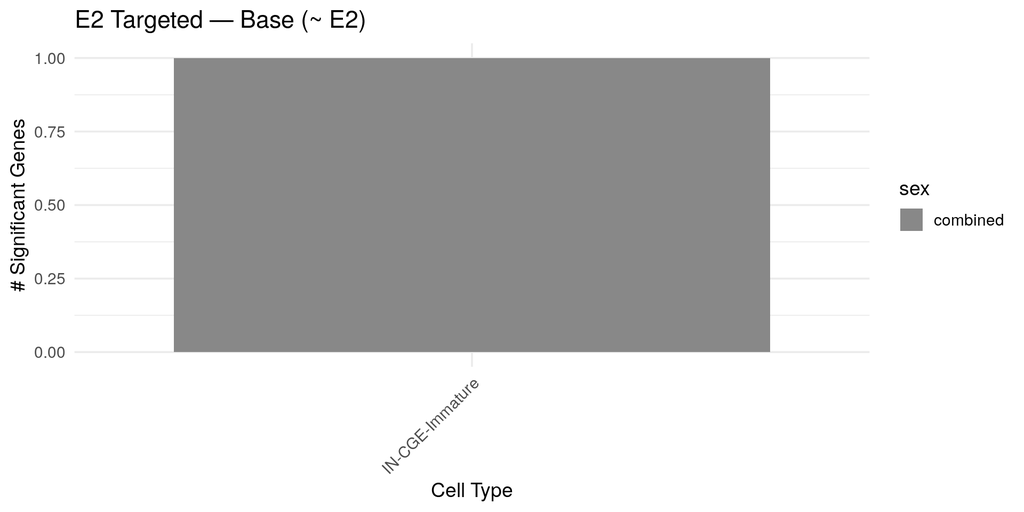

```r
p_e2_base
```

### Base + Sex

```r
p_e2_sex <- plot_sig_gene_summary(
  summarize_sig_genes(e2_results$sex$combined_results),
  "E2 Targeted — Base + Sex (~ E2 + Sex)"
)
save_dual_format(p_e2_sex, file.path(e2_out_dir, "sex"),
                 "E2_targeted_sex_summary")
```

```
## Saved: E2_targeted_sex_summary.png  +  svg/E2_targeted_sex_summary.svg
```

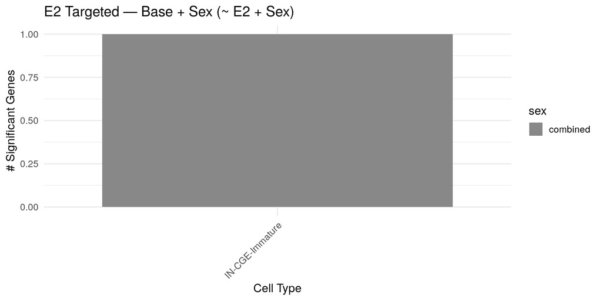

```r
p_e2_sex
```

### Base + Batch

```r
p_e2_batch <- plot_sig_gene_summary(
  summarize_sig_genes(e2_results$batch$combined_results),
  "E2 Targeted — Base + Batch (~ E2 + batch1_frac)"
)
save_dual_format(p_e2_batch, file.path(e2_out_dir, "batch"),
                 "E2_targeted_batch_summary")
```

```
## Saved: E2_targeted_batch_summary.png  +  svg/E2_targeted_batch_summary.svg
```

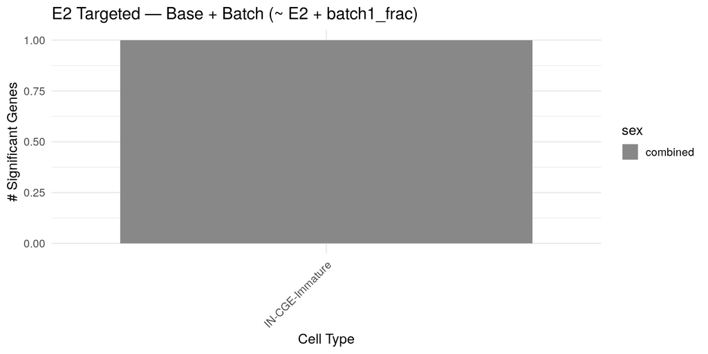

```r
p_e2_batch
```

### Base + Sex + Batch

```r
p_e2_sb <- plot_sig_gene_summary(
  summarize_sig_genes(e2_results$sex_batch$combined_results),
  "E2 Targeted — Base + Sex + Batch (~ E2 + Sex + batch1_frac)"
)
save_dual_format(p_e2_sb, file.path(e2_out_dir, "sex_batch"),
                 "E2_targeted_sex_batch_summary")
```

```
## Saved: E2_targeted_sex_batch_summary.png  +  svg/E2_targeted_sex_batch_summary.svg
```

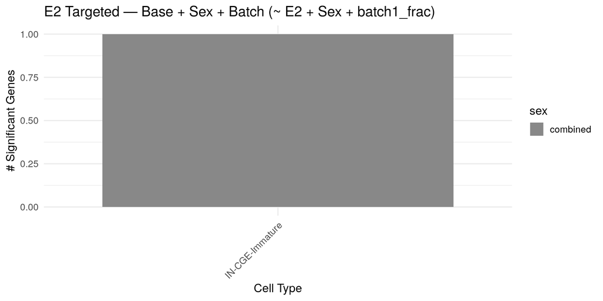

```r
p_e2_sb
```

```r
purrr::walk(model_specs_e2, function(spec) {
  plot_top_genes_from_subsets(
    e2_results[[spec$label]]$by_group_data,
    output_dir = file.path(e2_out_dir, spec$dir_suffix),
    hormone    = "E2"
  )
})
```

```
## Number of groups to plot: 10
```

```
##  Plotting group: Astrocyte-Immature_combined
```

```
## - Significant genes (FDR < 0.1, |logFC| >= 0.25): 0
```

```
## No valid plots for group
```

```
##  Plotting group: EN-IT-Immature_combined
```

```
## - Significant genes (FDR < 0.1, |logFC| >= 0.25): 0
```

```
## No valid plots for group
```

```
##  Plotting group: EN-L6-IT_combined
```

```
## - Significant genes (FDR < 0.1, |logFC| >= 0.25): 0
```

```
## No valid plots for group
```

```
##  Plotting group: EN-L6b_combined
```

```
## - Significant genes (FDR < 0.1, |logFC| >= 0.25): 0
```

```
## No valid plots for group
```

```
##  Plotting group: EN-Newborn_combined
```

```
## - Significant genes (FDR < 0.1, |logFC| >= 0.25): 0
```

```
## No valid plots for group
```

```
##  Plotting group: EN-Non-IT-Immature_combined
```

```
## - Significant genes (FDR < 0.1, |logFC| >= 0.25): 0
```

```
## No valid plots for group
```

```
##  Plotting group: IN-CGE-Immature_combined
```

```
## - Significant genes (FDR < 0.1, |logFC| >= 0.25): 1
```

```
##     Plotting gene: RPH3A (adj. p-value: 0.0183)
```

```
## Saved: IN-CGE-Immature_combined_top_genes.png  +  svg/IN-CGE-Immature_combined_top_genes.svg
##   Saved plot for IN-CGE-Immature_combined
##  Plotting group: IN-MGE-Immature_combined
## - Significant genes (FDR < 0.1, |logFC| >= 0.25): 0
## No valid plots for group
##  Plotting group: IN-MGE-SST_combined
## - Significant genes (FDR < 0.1, |logFC| >= 0.25): 0
## No valid plots for group
##  Plotting group: IPC-EN_combined
## - Significant genes (FDR < 0.1, |logFC| >= 0.25): 0
## No valid plots for group
## Number of groups to plot: 10
##  Plotting group: Astrocyte-Immature_combined
## - Significant genes (FDR < 0.1, |logFC| >= 0.25): 0
## No valid plots for group
##  Plotting group: EN-IT-Immature_combined
## - Significant genes (FDR < 0.1, |logFC| >= 0.25): 0
## No valid plots for group
##  Plotting group: EN-L6-IT_combined
## - Significant genes (FDR < 0.1, |logFC| >= 0.25): 0
## No valid plots for group
##  Plotting group: EN-L6b_combined
## - Significant genes (FDR < 0.1, |logFC| >= 0.25): 0
## No valid plots for group
##  Plotting group: EN-Newborn_combined
## - Significant genes (FDR < 0.1, |logFC| >= 0.25): 0
## No valid plots for group
##  Plotting group: EN-Non-IT-Immature_combined
## - Significant genes (FDR < 0.1, |logFC| >= 0.25): 0
## No valid plots for group
##  Plotting group: IN-CGE-Immature_combined
## - Significant genes (FDR < 0.1, |logFC| >= 0.25): 1
##     Plotting gene: RPH3A (adj. p-value: 0.0163)
```

```
## Saved: IN-CGE-Immature_combined_top_genes.png  +  svg/IN-CGE-Immature_combined_top_genes.svg
##   Saved plot for IN-CGE-Immature_combined
##  Plotting group: IN-MGE-Immature_combined
## - Significant genes (FDR < 0.1, |logFC| >= 0.25): 0
## No valid plots for group
##  Plotting group: IN-MGE-SST_combined
## - Significant genes (FDR < 0.1, |logFC| >= 0.25): 0
## No valid plots for group
##  Plotting group: IPC-EN_combined
## - Significant genes (FDR < 0.1, |logFC| >= 0.25): 0
## No valid plots for group
## Number of groups to plot: 10
##  Plotting group: Astrocyte-Immature_combined
## - Significant genes (FDR < 0.1, |logFC| >= 0.25): 0
## No valid plots for group
##  Plotting group: EN-IT-Immature_combined
## - Significant genes (FDR < 0.1, |logFC| >= 0.25): 0
## No valid plots for group
##  Plotting group: EN-L6-IT_combined
## - Significant genes (FDR < 0.1, |logFC| >= 0.25): 0
## No valid plots for group
##  Plotting group: EN-L6b_combined
## - Significant genes (FDR < 0.1, |logFC| >= 0.25): 0
## No valid plots for group
##  Plotting group: EN-Newborn_combined
## - Significant genes (FDR < 0.1, |logFC| >= 0.25): 0
## No valid plots for group
##  Plotting group: EN-Non-IT-Immature_combined
## - Significant genes (FDR < 0.1, |logFC| >= 0.25): 0
## No valid plots for group
##  Plotting group: IN-CGE-Immature_combined
## - Significant genes (FDR < 0.1, |logFC| >= 0.25): 1
##     Plotting gene: RPH3A (adj. p-value: 0.0255)
```

```
## Saved: IN-CGE-Immature_combined_top_genes.png  +  svg/IN-CGE-Immature_combined_top_genes.svg
##   Saved plot for IN-CGE-Immature_combined
##  Plotting group: IN-MGE-Immature_combined
## - Significant genes (FDR < 0.1, |logFC| >= 0.25): 0
## No valid plots for group
##  Plotting group: IN-MGE-SST_combined
## - Significant genes (FDR < 0.1, |logFC| >= 0.25): 0
## No valid plots for group
##  Plotting group: IPC-EN_combined
## - Significant genes (FDR < 0.1, |logFC| >= 0.25): 0
## No valid plots for group
## Number of groups to plot: 10
##  Plotting group: Astrocyte-Immature_combined
## - Significant genes (FDR < 0.1, |logFC| >= 0.25): 0
## No valid plots for group
##  Plotting group: EN-IT-Immature_combined
## - Significant genes (FDR < 0.1, |logFC| >= 0.25): 0
## No valid plots for group
##  Plotting group: EN-L6-IT_combined
## - Significant genes (FDR < 0.1, |logFC| >= 0.25): 0
## No valid plots for group
##  Plotting group: EN-L6b_combined
## - Significant genes (FDR < 0.1, |logFC| >= 0.25): 0
## No valid plots for group
##  Plotting group: EN-Newborn_combined
## - Significant genes (FDR < 0.1, |logFC| >= 0.25): 0
## No valid plots for group
##  Plotting group: EN-Non-IT-Immature_combined
## - Significant genes (FDR < 0.1, |logFC| >= 0.25): 0
## No valid plots for group
##  Plotting group: IN-CGE-Immature_combined
## - Significant genes (FDR < 0.1, |logFC| >= 0.25): 1
##     Plotting gene: RPH3A (adj. p-value: 0.0191)
```

```
## Saved: IN-CGE-Immature_combined_top_genes.png  +  svg/IN-CGE-Immature_combined_top_genes.svg
##   Saved plot for IN-CGE-Immature_combined
##  Plotting group: IN-MGE-Immature_combined
## - Significant genes (FDR < 0.1, |logFC| >= 0.25): 0
## No valid plots for group
##  Plotting group: IN-MGE-SST_combined
## - Significant genes (FDR < 0.1, |logFC| >= 0.25): 0
## No valid plots for group
##  Plotting group: IPC-EN_combined
## - Significant genes (FDR < 0.1, |logFC| >= 0.25): 0
## No valid plots for group
```

## Progesterone — Pseudobulk & Models

Note: Piechota P4 pool is small (≤9 genes after conversion). Cell types with fewer than 3 genes surviving the rowSums filter will be silently dropped.

```r
targeted_p4 <- detect_outliers(targeted_raw, "P4")
cat("P4 samples after outlier removal:", nrow(targeted_p4), "\n")
```

```
## P4 samples after outlier removal: 41
```

```r
pb_p4_full <- merge_hormone_metadata(
  pb_base, targeted_p4,
  pb_sample_pattern = pb_sample_pattern, min_cells = 30
) %>% add_batch_fraction(SSD_data)

pb_p4 <- subset_pb_to_pool(pb_p4_full, pool_p4, "P4")
```

```
## P4: 3 pool genes → 3 in pseudobulk (100.0%), 0 absent
```

Sex-combined (`analyze_hormone_combined()`); min 21 samples per group.

```r
p4_out_dir <- file.path(out_dir_base, "progesterone")
dir.create(p4_out_dir, showWarnings = FALSE, recursive = TRUE)

model_specs_p4 <- list(
  list(label = "base",      fn = run_voom_lm,           dir_suffix = "base"),
  list(label = "sex",       fn = run_voom_lm_sex,       dir_suffix = "sex"),
  list(label = "batch",     fn = run_voom_lm_batch,     dir_suffix = "batch"),
  list(label = "sex_batch", fn = run_voom_lm_sex_batch, dir_suffix = "sex_batch")
)

p4_results <- purrr::map(model_specs_p4, function(spec) {
  cat("\n=== P4 model:", spec$label, "===\n")
  res <- analyze_hormone_combined(
    pb_p4$counts, pb_p4$metadata,
    hormone               = "P4",
    min_samples           = 21,
    count_threshold       = 2,
    gene_sample_threshold = 3,
    model                 = spec$fn
  )
  out_sub <- file.path(p4_out_dir, spec$dir_suffix)
  dir.create(out_sub, showWarnings = FALSE, recursive = TRUE)
  write_csv(res$combined_results,
            file.path(out_sub, glue("P4_{spec$dir_suffix}_results.csv")))
  res
})
```

```
##
## === P4 model: base ===
##
## Group: Astrocyte-Immature
## Initial number of samples: 24
## Min samples required (fixed floor): 21
## Genes passing manual filter: 3
## Samples with non-zero hormone: 24
## Final sample size: 24
##
## Group: Cajal-Retzius cell
## Initial number of samples: 6
## Min samples required (fixed floor): 21
## Genes passing manual filter: 1
## Samples with non-zero hormone: 6
## Group removed: insufficient non-zero hormone values 6
##
## Group: EN-IT-Immature
## Initial number of samples: 34
## Min samples required (fixed floor): 21
## Genes passing manual filter: 3
## Samples with non-zero hormone: 34
## Final sample size: 34
##
## Group: EN-L4-IT
## Initial number of samples: 12
## Min samples required (fixed floor): 21
## Genes passing manual filter: 3
## Samples with non-zero hormone: 12
## Group removed: insufficient non-zero hormone values 12
##
## Group: EN-L5_6-NP
## Initial number of samples: 17
## Min samples required (fixed floor): 21
## Genes passing manual filter: 2
## Samples with non-zero hormone: 17
## Group removed: insufficient non-zero hormone values 17
##
## Group: EN-L5-IT
## Initial number of samples: 1
```

[output cut: 685 more lines]

```
## Genes passing manual filter: 2
## Samples with non-zero hormone: 13
## Group removed: insufficient non-zero hormone values 13
##
## Group: Unknown
## Initial number of samples: 3
## Min samples required (fixed floor): 21
## Genes passing manual filter: 0
## Group removed: no genes passed the filter
##
## Group: Vascular
## Initial number of samples: 1
## Min samples required (fixed floor): 21
## Genes passing manual filter: 0
## Group removed: no genes passed the filter
```

```r
names(p4_results) <- purrr::map_chr(model_specs_p4, "label")
```

## Progesterone — Results

```r
cross_p4 <- purrr::imap_dfr(p4_results, function(res, label) {
  summarize_sig_genes(res$combined_results) %>%
    dplyr::mutate(model = label)
})

knitr::kable(
  cross_p4 %>%
    dplyr::select(model, cell_type, num_sig_genes) %>%
    dplyr::arrange(model, desc(num_sig_genes)),
  caption = "P4 targeted: significant genes (FDR < 0.10, |logFC| ≥ 0.25)"
)
```

P4 targeted: significant genes (FDR < 0.10, |logFC| ≥ 0.25)

| model | cell_type | num_sig_genes |
| --- | --- | --- |

```r
cross_p4 %>%
  dplyr::group_by(model) %>%
  dplyr::summarise(total = sum(num_sig_genes), .groups = "drop") %>%
  knitr::kable(caption = "P4 targeted: total significant gene-cell_type pairs per model")
```

P4 targeted: total significant gene-cell_type pairs per model

| model | total |
| --- | --- |

### Base

```r
p_p4_base <- plot_sig_gene_summary(
  summarize_sig_genes(p4_results$base$combined_results),
  "P4 Targeted — Base (~ P4)"
)
save_dual_format(p_p4_base, file.path(p4_out_dir, "base"),
                 "P4_targeted_base_summary")
```

```
## Saved: P4_targeted_base_summary.png  +  svg/P4_targeted_base_summary.svg
```

[figure not shown]

```r
p_p4_base
```

### Base + Sex

```r
p_p4_sex <- plot_sig_gene_summary(
  summarize_sig_genes(p4_results$sex$combined_results),
  "P4 Targeted — Base + Sex (~ P4 + Sex)"
)
save_dual_format(p_p4_sex, file.path(p4_out_dir, "sex"),
                 "P4_targeted_sex_summary")
```

```
## Saved: P4_targeted_sex_summary.png  +  svg/P4_targeted_sex_summary.svg
```

[figure not shown]

```r
p_p4_sex
```

### Base + Batch

```r
p_p4_batch <- plot_sig_gene_summary(
  summarize_sig_genes(p4_results$batch$combined_results),
  "P4 Targeted — Base + Batch (~ P4 + batch1_frac)"
)
save_dual_format(p_p4_batch, file.path(p4_out_dir, "batch"),
                 "P4_targeted_batch_summary")
```

```
## Saved: P4_targeted_batch_summary.png  +  svg/P4_targeted_batch_summary.svg
```

[figure not shown]

```r
p_p4_batch
```

### Base + Sex + Batch

```r
p_p4_sb <- plot_sig_gene_summary(
  summarize_sig_genes(p4_results$sex_batch$combined_results),
  "P4 Targeted — Base + Sex + Batch (~ P4 + Sex + batch1_frac)"
)
save_dual_format(p_p4_sb, file.path(p4_out_dir, "sex_batch"),
                 "P4_targeted_sex_batch_summary")
```

```
## Saved: P4_targeted_sex_batch_summary.png  +  svg/P4_targeted_sex_batch_summary.svg
```

[figure not shown]

```r
p_p4_sb
```

```r
purrr::walk(model_specs_p4, function(spec) {
  plot_top_genes_from_subsets(
    p4_results[[spec$label]]$by_group_data,
    output_dir = file.path(p4_out_dir, spec$dir_suffix),
    hormone    = "P4"
  )
})
```

```
## Number of groups to plot: 10
```

```
##  Plotting group: Astrocyte-Immature_combined
```

```
## - Significant genes (FDR < 0.1, |logFC| >= 0.25): 0
```

```
## No valid plots for group
```

```
##  Plotting group: EN-IT-Immature_combined
```

```
## - Significant genes (FDR < 0.1, |logFC| >= 0.25): 0
```

```
## No valid plots for group
```

```
##  Plotting group: EN-L6-IT_combined
```

```
## - Significant genes (FDR < 0.1, |logFC| >= 0.25): 0
```

```
## No valid plots for group
```

```
##  Plotting group: EN-L6b_combined
```

```
## - Significant genes (FDR < 0.1, |logFC| >= 0.25): 0
```

```
## No valid plots for group
```

```
##  Plotting group: EN-Newborn_combined
```

```
## - Significant genes (FDR < 0.1, |logFC| >= 0.25): 0
```

```
## No valid plots for group
```

```
##  Plotting group: EN-Non-IT-Immature_combined
```

```
## - Significant genes (FDR < 0.1, |logFC| >= 0.25): 0
```

```
## No valid plots for group
```

```
##  Plotting group: IN-CGE-Immature_combined
```

```
## - Significant genes (FDR < 0.1, |logFC| >= 0.25): 0
```

```
## No valid plots for group
```

```
##  Plotting group: IN-MGE-Immature_combined
```

```
## - Significant genes (FDR < 0.1, |logFC| >= 0.25): 0
```

```
## No valid plots for group
```

```
##  Plotting group: IN-MGE-SST_combined
```

```
## - Significant genes (FDR < 0.1, |logFC| >= 0.25): 0
```

```
## No valid plots for group
```

```
##  Plotting group: IPC-EN_combined
```

```
## - Significant genes (FDR < 0.1, |logFC| >= 0.25): 0
```

```
## No valid plots for group
```

```
## Number of groups to plot: 10
```

```
##  Plotting group: Astrocyte-Immature_combined
```

```
## - Significant genes (FDR < 0.1, |logFC| >= 0.25): 0
```

```
## No valid plots for group
```

```
##  Plotting group: EN-IT-Immature_combined
```

```
## - Significant genes (FDR < 0.1, |logFC| >= 0.25): 0
```

```
## No valid plots for group
```

```
##  Plotting group: EN-L6-IT_combined
```

```
## - Significant genes (FDR < 0.1, |logFC| >= 0.25): 0
```

```
## No valid plots for group
```

```
##  Plotting group: EN-L6b_combined
```

```
## - Significant genes (FDR < 0.1, |logFC| >= 0.25): 0
```

```
## No valid plots for group
```

```
##  Plotting group: EN-Newborn_combined
```

```
## - Significant genes (FDR < 0.1, |logFC| >= 0.25): 0
```

```
## No valid plots for group
```

```
##  Plotting group: EN-Non-IT-Immature_combined
```

```
## - Significant genes (FDR < 0.1, |logFC| >= 0.25): 0
```

```
## No valid plots for group
```

```
##  Plotting group: IN-CGE-Immature_combined
```

```
## - Significant genes (FDR < 0.1, |logFC| >= 0.25): 0
```

```
## No valid plots for group
```

```
##  Plotting group: IN-MGE-Immature_combined
```

```
## - Significant genes (FDR < 0.1, |logFC| >= 0.25): 0
```

```
## No valid plots for group
```

```
##  Plotting group: IN-MGE-SST_combined
```

```
## - Significant genes (FDR < 0.1, |logFC| >= 0.25): 0
```

```
## No valid plots for group
```

```
##  Plotting group: IPC-EN_combined
```

```
## - Significant genes (FDR < 0.1, |logFC| >= 0.25): 0
```

```
## No valid plots for group
```

```
## Number of groups to plot: 10
```

```
##  Plotting group: Astrocyte-Immature_combined
```

```
## - Significant genes (FDR < 0.1, |logFC| >= 0.25): 0
```

```
## No valid plots for group
```

```
##  Plotting group: EN-IT-Immature_combined
```

```
## - Significant genes (FDR < 0.1, |logFC| >= 0.25): 0
```

```
## No valid plots for group
```

```
##  Plotting group: EN-L6-IT_combined
```

```
## - Significant genes (FDR < 0.1, |logFC| >= 0.25): 0
```

```
## No valid plots for group
```

```
##  Plotting group: EN-L6b_combined
```

```
## - Significant genes (FDR < 0.1, |logFC| >= 0.25): 0
```

```
## No valid plots for group
```

```
##  Plotting group: EN-Newborn_combined
```

```
## - Significant genes (FDR < 0.1, |logFC| >= 0.25): 0
```

```
## No valid plots for group
```

```
##  Plotting group: EN-Non-IT-Immature_combined
```

```
## - Significant genes (FDR < 0.1, |logFC| >= 0.25): 0
```

```
## No valid plots for group
```

```
##  Plotting group: IN-CGE-Immature_combined
```

```
## - Significant genes (FDR < 0.1, |logFC| >= 0.25): 0
```

```
## No valid plots for group
```

```
##  Plotting group: IN-MGE-Immature_combined
```

```
## - Significant genes (FDR < 0.1, |logFC| >= 0.25): 0
```

```
## No valid plots for group
```

```
##  Plotting group: IN-MGE-SST_combined
```

```
## - Significant genes (FDR < 0.1, |logFC| >= 0.25): 0
```

```
## No valid plots for group
```

```
##  Plotting group: IPC-EN_combined
```

```
## - Significant genes (FDR < 0.1, |logFC| >= 0.25): 0
```

```
## No valid plots for group
```

```
## Number of groups to plot: 10
```

```
##  Plotting group: Astrocyte-Immature_combined
```

```
## - Significant genes (FDR < 0.1, |logFC| >= 0.25): 0
```

```
## No valid plots for group
```

```
##  Plotting group: EN-IT-Immature_combined
```

```
## - Significant genes (FDR < 0.1, |logFC| >= 0.25): 0
```

```
## No valid plots for group
```

```
##  Plotting group: EN-L6-IT_combined
```

```
## - Significant genes (FDR < 0.1, |logFC| >= 0.25): 0
```

```
## No valid plots for group
```

```
##  Plotting group: EN-L6b_combined
```

```
## - Significant genes (FDR < 0.1, |logFC| >= 0.25): 0
```

```
## No valid plots for group
```

```
##  Plotting group: EN-Newborn_combined
```

```
## - Significant genes (FDR < 0.1, |logFC| >= 0.25): 0
```

```
## No valid plots for group
```

```
##  Plotting group: EN-Non-IT-Immature_combined
```

```
## - Significant genes (FDR < 0.1, |logFC| >= 0.25): 0
```

```
## No valid plots for group
```

```
##  Plotting group: IN-CGE-Immature_combined
```

```
## - Significant genes (FDR < 0.1, |logFC| >= 0.25): 0
```

```
## No valid plots for group
```

```
##  Plotting group: IN-MGE-Immature_combined
```

```
## - Significant genes (FDR < 0.1, |logFC| >= 0.25): 0
```

```
## No valid plots for group
```

```
##  Plotting group: IN-MGE-SST_combined
```

```
## - Significant genes (FDR < 0.1, |logFC| >= 0.25): 0
```

```
## No valid plots for group
```

```
##  Plotting group: IPC-EN_combined
```

```
## - Significant genes (FDR < 0.1, |logFC| >= 0.25): 0
```

```
## No valid plots for group
```

## Cross-Hormone Summary

```r
summary_all <- dplyr::bind_rows(
  cross_tt %>% dplyr::group_by(model) %>%
    dplyr::summarise(total_sig = sum(num_sig_genes), .groups = "drop") %>%
    dplyr::mutate(hormone = "TT", pool_size = nrow(pool_tt)),
  cross_e2 %>% dplyr::group_by(model) %>%
    dplyr::summarise(total_sig = sum(num_sig_genes), .groups = "drop") %>%
    dplyr::mutate(hormone = "E2", pool_size = nrow(pool_e2)),
  cross_p4 %>% dplyr::group_by(model) %>%
    dplyr::summarise(total_sig = sum(num_sig_genes), .groups = "drop") %>%
    dplyr::mutate(hormone = "P4", pool_size = nrow(pool_p4))
) %>%
  dplyr::select(hormone, pool_size, model, total_sig)

knitr::kable(summary_all,
  caption = "Targeted analysis summary: significant gene-cell_type associations",
  col.names = c("Hormone", "Pool size", "Model", "Sig. gene-cell_type pairs"))
```

Targeted analysis summary: significant gene-cell_type associations

| Hormone | Pool size | Model | Sig. gene-cell_type pairs |
| --- | --- | --- | --- |
| E2 | 39 | base | 1 |
| E2 | 39 | batch | 1 |
| E2 | 39 | sex | 1 |
| E2 | 39 | sex_batch | 1 |

```r
write_csv(summary_all,
          file.path(out_dir_base, "targeted_cross_hormone_summary.csv"))
```

## AI Assistance Disclosure

Code in this script was developed with assistance from Claude (Anthropic). All AI-generated code was reviewed, validated, and adapted by the author.